# CoronaNet Project Goals

## Why do we need Project Goals?

This project has always had to deal with **uncertainty** given that we are collecting data in real time and we thus cannot know ahead of time:

- How long the pandemic will last and how governments will react to it
- How many people are willing to assess, plan, code, clean and validate data

Having project-wide goals helps us **coordinate** and make sure that despite the uncertainty, we are doing our best to:

- Collect data for all over the world for the same time periods
- Ensure high quality in our data collection efforts

**Having complete and clean data for many countries over the same time period is crucial to say anything about what the drivers and effects of COVID-19 government policies are**

- In terms of both ethics and feasibility, our ability to use experiments to figure out which policies are effective or what drives them is limited
- We can however learn something about the drivers and effects of the pandemic by comparing what different countries do and:
  - the more variation there is in what different countries do, the more we can potentially answer these questions (e.g. if everyone does the same thing, it is hard to say what would have happened if X other thing happened instead)
  - the bigger our sample (the more countries over time) we have to compare, the more generalizable our findings (the more the findings will apply not just to a special subset of units/countries, but to a larger group of units/countries)

## What are the Project Goals?

The **overall** project goals are to:

- ensure **complete** and **clean** data for all countries.

The time period for which we aim to collect **complete** and **clean** data will be different depending on whether a country is a spotlight country or a capsule country and whether subantional data collection is involved:

[figure not shown]

**Spotlight national and subnational countries**: Document policies made up until 10/2021 (hard goal)**

- EU27 Countries + Eurasia + Senegal
  - Austria, Belgium, Belarus, Bulgaria, Croatia, Cyprus, Czechia, Denmark, Estonia, Finland, **France**, **Germany**, Greece, Hungary, Ireland, **Italy**, Kazakhstan , Kyrgyzstan, Latvia, Lithuania, Luxembourg, Malta, Netherlands, Poland, Portugal, Romania, **Russia**, Senegal, Slovakia, Slovenia, **Spain**, Sweden, Tajikistan, Turkmenistan, Ukraine, and Uzbekistan
  - Subnational data collection for bolded countries

**Capsule National Countries**: Document policies made up until 03/2021 (hard goal) + 10/2021 (soft goal)**

- Afghanistan, Albania, Algeria, Andorra, Angola, Antigua and Barbuda, Argentina, Armenia, Azerbaijan, Bahamas, Bahrain, Bangladesh, Barbados, Belarus, Belize, Benin, Bhutan, Bolivia, Bosnia and Herzegovina, Botswana, Brunei, Burkina Faso, Burundi, Cabo Verde, Cambodia, Cameroon, Central African Republic, Chad, Chile, Colombia, Comoros, Costa Rica, Cuba, Democratic Republic of the Congo, Djibouti, Dominica, Dominican Republic, Ecuador, Egypt, El Salvador, Equatorial Guinea, Eritrea, Eswatini, Ethiopia, Fiji, Gabon, Gambia, Georgia, Ghana, Grenada, Guatemala, Guinea, Guinea-Bissau, Guyana, Haiti, Honduras, Hong Kong, Iceland, Indonesia, Iran, Iraq, Israel, Ivory Coast, Jamaica, Jordan, Kenya, Kiribati, Kosovo, Kuwait, Laos, Lebanon, Lesotho, Liberia, Libya, Liechtenstein, Macau, Madagascar, Malawi, Malaysia, Maldives, Mali, Marshall Islands, Mauritania, Mauritius, Micronesia, Moldova, Monaco, Mongolia, Montenegro, Morocco, Mozambique, Myanmar, Namibia, Nauru, Nepal, New Zealand, Nicaragua, Niger, North Korea, North Macedonia, Northern Cyprus, Norway, Oman, Pakistan, Palau, Paletsine, Panama, Papua New Guinea, Paraguay, Peru, Philippines, Qatar, Republic of the Congo, Rwanda, Saint Kitts and Nevis, Saint Lucia, Saint Vincent and the Grenadines, Samoa, San Marino, Sao Tome and Principe, Saudi Arabia, Serbia, Seychelles, Sierra Leone, Singapore, Solomon Islands, Somalia, South Africa, South Korea, South Sudan, Sri Lanka, Sudan, Suriname, Syria, Taiwan, Tanzania, Thailand, Timor Leste, Togo, Tonga, Trinidad and Tobago, Tunisia, Turkey, Tuvalu, Uganda, United Arab Emirates, United Kingdom, Uruguay, Vanuatu, Vatican, Venezuela, Vietnam, Yemen, Zambia, Zimbabwe

**Capsule Subnational Countries**: Document policies made up until 10/2020 (hard goal) + 10/2021 (soft goal)**

- Australia, Brazil, Canada, China, India, Japan, Mexico, Nigeria, Switzerland, United States

What is ‘complete’ data?

What is ‘clean’ data?

**Complete data for a given time period:**

- *in the abstract* mean documenting all the COVID-19 government policies that a given government made.
- *in practice*, **complete data** is impossible to define beforehand; if we knew what the complete set of policies there were to code, our jobs would already be halfway done!

We can only judge the ‘completeness’ of the data for any given region using:

- **RA internal assessment** of whether the policies captured in the CoronaNet dataset for their region represent a faithful representation of government policies made in that region for a given time period.
- **External comparison** of the number and types of policies that other datasets have captured and subsequently **integrating external data**

*Why might there be incomplete data?*

- Finding information about policies can be very difficult especially for countries with [low state capacity](https://www.coronanet-project.org/low_state_capacity)
- Some countries may have not had an RA or inattentive RAs for long periods of time

**Clean data means that for each observation:**

- **all relevant information is available** and;
- **correctly coded according to the latest taxonomy**

We can judge the ‘cleanliness’ of the data for any given region by

- **RA internal assessment** of whether their region are coded in a way that consistently conforms to the last version of the CoronaNet taxonomy, which will then later be verified by a country or regional manager,
- **Automated assessment** of problems in the data that can be identified through R code.

*Why might there be missing information for a given variable?*

- We’ve made a number of changes to the original survey, launched March 28, 2020, in order to keep track of what new things governments have done since then. —> When questions are added later to the survey however, this data is missing for earlier observations and must subsequently be backcoded

*Why might there be incorrectly coded information for a given variable?*

- When there are new options or new questions added later, earlier data coded using the older taxonomy may not match the new taxonomy
- Coding data is hard especially with our taxonomy and its only natural that people make mistakes =)

## What does this mean for me?

**I am coding for a **Spotlight national or subnational country**

Your RM/CM will have **quarterly-specific goals** designed to help reach the overall project goals which takes into account what the data looks like for your country or subnational region.

In general however, **all spotlight national or subnational countries** should work in coordination as follows:

- Stage 1: Work on collecting **complete** and **clean** data for each policy type until October 1, 2020
- Stage 2: Work on collecting **complete** and **clean** data for each policy type until March 1, 2021
- Stage 3: Work on collecting **complete** and **clean** data for each policy type until June 1, 2021
- Stage 4: Work on collecting **complete** and **clean** data for each policy type until October 1, 2021

For each stage, you should work on making sure the data in your region is **complete** and **clean** before moving on to the next stage.

- *If your country or sub-national region has reached ‘Stage 4’* you should **not** code any further for your country or sub-national region— please coordinate with your regional/country manager to help get other data for other regions **complete** and **clean** at lower stages.

**I am coding for a **Capsule National Country**

Your RM/CM will have **quarterly-specific goals** designed to help reach the overall project goals which takes into account what the data looks like for your country.

In general however, **all capsule national countries** should work in coordination as follows:

- Stage 1: Work on collecting **complete** and **clean** data for each policy type until October 1, 2020
- Stage 2: Work on collecting **complete** and **clean** data for each policy type until March 1, 2021

For each stage, you should work on making sure the data in your region is **complete** and **clean** before moving on to the next stage.

- *If your country has reached ‘Stage 2’* you should **not** code any further for your country or subnational region— please coordinate with your regional/country manager to help get other data for other regions **complete** and **clean** at Stage 1
- *If the great majority of countries have reached Stage 2’*, RAs coding for **all capsule national countries** may continue coding until June 1, 2021 —> if and when this happens, a general announcement will be made by the PIs in conferral with regional and country managers.

**I am coding for a **Capsule Subnational Country**

Your RM/CM will have **quarterly-specific goals** designed to help reach the overall project goals which takes into account what the data looks like for your country.

In general however, **all capsule subnational countries** should work in coordination as follows:

- Stage 1: Work on collecting **complete** and **clean** data for each policy type until October 1, 2020

*If your subnational region has reached ‘Stage 1’* you should **not** code any further for your subnational region— please coordinate with your country manager to help get data for other subnational regions in your country **complete** and **clean** at Stage 1

**I am a **regional or country manager**

- Regional and country managers should devise region or country specific quarterly goals to plan for reaching each of the project-level goals. More details will be forthcoming.

## What tools and processes will we use to help us reach these goals?

### Workflow Overview

In general, the workflow for achieving these goals will look like:

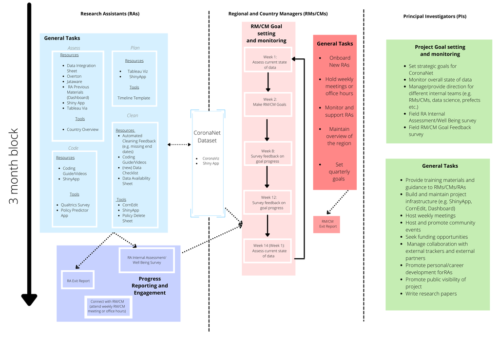

### Workflow Timeline

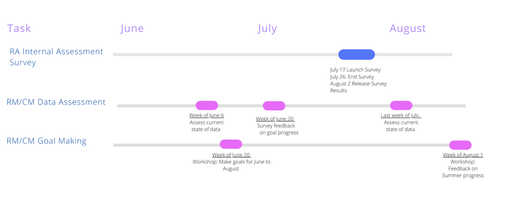

### Workflow Table

To access the some of the elements listed in the workflow Chart, please see the table below:

[output not shown]

## FAQs

**How should I prioritize coding different policy types under this overall strategy?**

As before, wherever possible, RAs should still prioritize coding the following policy types first wherever possible. Having the same priorities for policy types also helps ensure consistency and completeness along this dimension of the data, which improves cross-regional analysis of the data for these policy types.

Group 1

- Lockdown
- Curfew
- Quarantine

Group 2:

- External Border Restrictions
- Internal Border Restrictins

Group 3:

- Restrictions of Mass Gatherings
- Social Distancing

Group 4

- Closure and Regulation of Schools
- Restrictions and Regulations of Businesses
- Restrictions and Regulations of Government Services

Group 5:

- Health Monitoring
- Health Testing
- Health Resources
- Hygiene

Group 6:

- Declaration of Emergencies
- New Task Forces
- Public Awareness Measures
- Anti-disinformation Measures

Group 7:

- COVID-19 Vaccines

**What do we do with the data checklists?**

We will be relying on the RA Internal Survey for much of the information that we used to get from the data checklists. However, if you’ve found them to be useful tools for yourself, we’ll still keep them around and you’re free to use them if you find them helpful!